# RNewsflow: Tools for analyzing content homogeneity and news diffusion using computational text analysis

## Aggregating the document similarity network

This package offers the `network.aggregate` function as a versatile way to aggregate the edges of the document similarity network based on the vertex attributes (i.e. the document meta information). The first argument is the network (in the `igraph` class). The second argument, for the `by` parameter, is a character vector to indicate one or more vertex attributes based on which the edges are aggregated. Optionally, the `by` characteristics can also be specified separately for `by.from` and `by.to`. This gives flexible control over the data, for instance to aggregate *from* sources *to* sourcetypes, or to aggregate scores for each source per month.

By default, the function returns the number of edges, as well as the number of nodes that is connected for both the `from` and `to` group. The number of nodes that is connected is only relevant if a threshold for similarity (edge weight) is used, so that whether or not an edge exists indicates whether or not two documents are similar. In addition, if an `edge.attribute` is given, this attribute will be aggregated using the function specified in `agg.FUN`. For the following example we include this to analyze the median of the `hourdiff` attribute.

```r
g.agg = network.aggregate(g, by='source',
                          edge.attribute='hourdiff',
                          agg.FUN=median)

e = get.data.frame(g.agg, 'edges')
head(e)
```

```
##          from          to edges agg.hourdiff from.V from.Vprop to.V
## 1  Newsagency  Newsagency   115         8.47     95     0.1591   99
## 2  Print NP 1  Newsagency    19         8.33     15     0.1020   18
## 3 Online NP 1  Newsagency   105         4.82     82     0.1775   94
## 4 Online NP 2  Newsagency    68         6.71     59     0.1415   62
## 5  Print NP 2  Newsagency    10        10.75     10     0.0763   10
## 6  Newsagency Online NP 1   435         1.27    381     0.6382  407
##   to.Vprop
## 1   0.1658
## 2   0.0302
## 3   0.1575
## 4   0.1039
## 5   0.0168
## 6   0.8810
```

## Inspecting and visualizing results

The final step is to interpret the aggregated network data, or to prepare this data for use in a different analysis. We already saw that the network data can be transformed to a common data.frame with the `get.data.frame` function. Alternatively, `igraph` has the `get.adjacency` function to return the values for one edge attribute as an adjacency matrix, with the vertices in the rows and columns. This is a good way to present the scores of the aggregated network.

```r
adj.m = get.adjacency(g.agg, attr= 'to.Vprop', sparse = FALSE)
round(adj.m, 2) # round on 2 decimals
```

```
##             Newsagency Print NP 1 Online NP 1 Online NP 2 Print NP 2
## Newsagency        0.17       0.24        0.88        0.82       0.34
## Print NP 1        0.03       0.03        0.05        0.04       0.02
## Online NP 1       0.16       0.22        0.11        0.33       0.31
## Online NP 2       0.10       0.18        0.26        0.08       0.31
## Print NP 2        0.02       0.01        0.03        0.07       0.01
```

Alternatively, an intuitive way to present the aggregated network is by visualizing it. For this we can use the visualization features of the `igraph` package. To make this more convenient, we also offer the `directed.network.plot` function. This is a wrapper for the plot.igraph function, which makes it easier to use different edge weight attributes and to use an edge threshold, and has default plotting parameters to work well for directed graphs with edge labels. For this example we use the `to.Vprop` edge attribute with a threshold of 0.2.

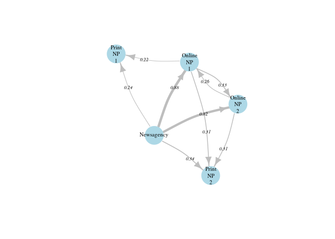

```r
directed.network.plot(g.agg, weight.var = 'to.Vprop',
                       weight.thres = 0.2)
```

For illustration, we can now see how the results change if we transform the network with the `only.first.match` function, which only counts edges to the first source that published a document.

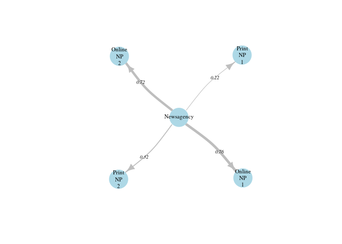

```r
g2 = only.first.match(g)
g2.agg = network.aggregate(g2, by='source',
                           edge.attribute='hourdiff',
                           agg.FUN=median)

directed.network.plot(g2.agg, weight.var = 'to.Vprop',
                       weight.thres = 0.2)
```

The first network is much more dense compared to the second. In particular, we see stronger edges between the print and online editions of the newspapers. In the second network only the edges from the news agency towards the print and online newspapers remain, meaning that edges between newspapers all score less than 0.2. This implies that many of the edges between newspapers that could be observed in the first network resulted from cases where both newspapers adopt the same news agency articles.

Note that the second network is not better per se. It is possible that the initial source of a message is not the direct source. For example, a blog might not have access to the news agency feed, and therefore only receive news agency messages if they are published by another source. Thus, the most suitable approach depends on the purpose of the analysis. One of the goals of creating this package is to facilitate a platform for scholars and professionals to develop best practices for different occasions.

## Alternative applications of this package

There are several alternative applications of the functions offered in this package that are not covered in this vignette. Here we briefly point out some of the more useful alternatives.

In the network.aggregate function it is possible to use different vertex attributes to aggregate the edges for `from` and `to` nodes. A particularly interesting application of this feature is to use the publication date in the aggregation. For instance, with the following settings, we can get the proportion of matched documents per day. Here we also demonstrate the `return.df` parameter in the `network.aggregate` function. This way the results are returned as a single data.frame in which relevant edge and vertex information is merged.

```r
V(g)$day = format(as.Date(V(g)$date), '%Y-%m-%d')
agg.perday = network.aggregate(g,
              by.from='sourcetype', by.to=c('sourcetype', 'day'),
              edge.attribute='hourdiff', agg.FUN=median,
              return.df=TRUE)


head(agg.perday[agg.perday$to.sourcetype == 'Online NP',
                c('from.sourcetype', 'to.sourcetype', 'to.day','to.Vprop')])
```

```
##    from.sourcetype to.sourcetype     to.day to.Vprop
## 66      Newsagency     Online NP 2013-06-01    0.789
## 67       Online NP     Online NP 2013-06-01    0.368
## 68        Print NP     Online NP 2013-06-01    0.263
## 69      Newsagency     Online NP 2013-06-02    0.778
## 70       Online NP     Online NP 2013-06-02    0.111
## 71      Newsagency     Online NP 2013-06-03    0.864
```

Looking at the *to.Vprop* score, we see that on 2013-06-01, 78.95% of *Online NP* messages match with previously published *Newsagency* messages[^9]. This way, the aggregated document similarity data can be analyzed as a time-series. For instance, to analyze whether seasonal effects or extra-media developments such as election campaigns affect content homogeneity or intermedia dynamics. The `return.df` feature is convenient for this purpose, because it directly matches all the vertex and edge attributes (as opposed to the `get.data.frame` function).

Another useful application of this feature is to only aggregate the `by.to` group, by using the document name in the `by.from` argument. This way, the data in the *by.to* group is aggregated for each individual message. In the following example we use this to see for each individual message whether it matches with later published messages in each sourcetype. This could for instance be used to analyze whether certain document level variables (e.g., news factors, sensationalism) make a message more likely to be adopted by other news outlets. We set the `edge.attribute` to “weight” and `agg.FUN` to max, so that for each document we can see how strong the strongest match with each source was.

```r
agg.perdoc = network.aggregate(g,
                  by.from='name', by.to='sourcetype',
                  edge.attribute='weight', agg.FUN=max,
                  return.df=TRUE)
docXsource = xtabs(agg.weight ~ from.name + to.sourcetype,
                   agg.perdoc, sparse = FALSE)
head(docXsource)
```

```
##            to.sourcetype
## from.name   Newsagency Online NP Print NP
##   147908507      0.400     0.425    0.000
##   148662598      0.000     0.767    0.000
##   150454094      0.520     0.528    0.000
##   150454102      0.000     0.895    0.000
##   150454110      0.000     0.402    0.000
##   150454167      0.000     0.996    0.000
```

Finally, note that we have now only compared documents with future documents. We thereby focus the analysis on news diffusion. To focus on content homogeneity, each document can be compared to both past and future documents. By measuring content homogeneity aggregated over time, patterns such as longitudinal trends can be analyzed.

# Conclusion and future improvements

We have demonstrated how the *RNewsflow* package can be used to perform a many-to-many comparison of documents. The primary focus and most important feature of this package is the `newsflow.compare` function. This function compares all documents that occur within a given time distance, which makes it computationally feasible for longitudinal data. Using this data, we can analyze to what extent different sources publish the same content and whether there are consistent patterns in who follows whom. The secondary focus of this package is to provide functions to organize, visualize and analyze the document similarity data within R. By enabling both the document comparison and analysis to be performed within R, this type of analysis becomes more accesible to scholars less versed in computational text analysis, and it becomes easier to share and replicate methods at a very detailed level.

The data input required for this analysis consists solely of textual documents and their corresponding publication date and source. Since no human coding is required, the package enables large scale comparative and longitudinal studies. Although the demonstration in this vignette used a moderate sized dataset, the `newsflow.compare` function can handle much larger data and is fast, thanks to a dedicated Rcpp (c++) implementation of sparse matrix multiplication for comparing documents within the given date window.

The validity of the method presented here relies on various factors; most importantly the type of data, the pre-processing and DTM preparation steps and the similarity threshold. It is thus recommended to use a gold standard, based on human interpretation, to test its validity. In a recent empirical study (author citation, forthcoming) we obtained good performance for whether documents addressed the same events and whether they contained identical phrases by determining thresholds based on a manually coded gold standard. Also, by using a news website that consistently referred to a news agency by name, we confirmed that we could reliably identify news agency influence for this format. Naturally, there are always limitations to the accuracy with which influence in news diffusion can be measured using only content analysis. However, we generally do not have access to other reliable information. The advantage of a content analysis based approach is that it can be used on a large scale and over long periods of time, without relying on often equally inaccurate self-reports of news workers. The current package contributes to the toolkit for this type of analysis.

Our goal is to continue developing this package as a specialized toolkit for analyzing the homogeneity and diffusion of news content. First of all, additional approaches for measuring whether documents are related will be added. Currently only a vector space model approach for calculating document similarity is implemented. For future versions alternative approaches such as language modeling will also be explored. In particular, we want to add measures to express the relation of documents over time in terms of probability and information gain. This would also allow us to define a more formal criterion for whether or not a relation exists, other than using a constant threshold for document similarity. Secondly, new methods for analyzing and visualizing the network data will be explored. In particular, methods will be implemented for analyzing patterns beyond dyadic ties between news outlets, building on techniques from the field of network analysis. To promote the involvement of other scholars and professionals in this development, the package is published entirely open-source. The source code is hosted on GitHub—https://github.com/kasperwelbers/RNewsflow.

# Practical code example

```r
library(RNewsflow)
library(quanteda)

# Prepare DTM
dtm = rnewsflow_dfm  ## copy demo data

tdd = term.day.dist(dtm)
dtm = dtm[,tdd$term[tdd$days.entropy.norm <= 0.3]]

dtm = dfm_tfidf(dtm)

# Prepare document similarity network
g = newsflow.compare(dtm, hour.window = c(-0.1,60),
                     min.similarity = 0.4)
g = filter.window(g, hour.window = c(6, 36),
                  to.vertices = V(g)$sourcetype == 'Print NP')

show.window(g, to.attribute = 'source')

g_subcomps = decompose.graph(g)
document.network.plot(g_subcomps[[2]], dtm=dtm)

g.agg = network.aggregate(g, by='source',
                          edge.attribute='hourdiff', agg.FUN=median)

get.adjacency(g.agg, attr='to.Vprop')
directed.network.plot(g.agg, weight.var = 'to.Vprop',
                      weight.thres=0.2)

g2 = only.first.match(g)
g2.agg = network.aggregate(g2, by='source',
                           edge.attribute='hourdiff', agg.FUN=median)

get.adjacency(g2.agg, attr='to.Vprop')
directed.network.plot(g2.agg, weight.var = 'to.Vprop',
                      weight.thres=0.2)
```

# References

Baum, Matthew A, and Tim Groeling. 2008. “New Media and the Polarization of American Political Discourse.” *Political Communication* 25 (4). Taylor & Francis: 345–65.

Bennett, W Lance, and Shanto Iyengar. 2008. “A New Era of Minimal Effects? The Changing Foundations of Political Communication.” *Journal of Communication* 58 (4). Wiley Online Library: 707–31.

Benoit, Kenneth. 2018. *Quanteda: Quantitative Analysis of Textual Data*. doi:10.5281/zenodo.1004683.

Blumler, Jay G, and Dennis Kavanagh. 1999. “The Third Age of Political Communication: Influences and Features.” *Political Communication* 16 (3). Taylor & Francis: 209–30.

Boczkowski, Pablo J, and Martin De Santos. 2007. “When More Media Equals Less News: Patterns of Content Homogenization in Argentina’s Leading Print and Online Newspapers.” *Political Communication* 24 (2). Taylor & Francis: 167–80.

Csardi, Gabor, and Tamas Nepusz. 2006. “The Igraph Software Package for Complex Network Research.” *InterJournal, Complex Systems* 1695 (5): 1–9.

Feinerer, Ingo, Kurt Hornik, and David Meyer. 2008. “Text Mining Infrastructure in R.” *Journal of Statistical Software* 25 (5): 1–54. http://www.jstatsoft.org/v25/i05.

Galtung, Johan, and Mari Holmboe Ruge. 1965. “The Structure of Foreign News the Presentation of the Congo, Cuba and Cyprus Crises in Four Norwegian Newspapers.” *Journal of Peace Research* 2 (1). Sage Publications: 64–90.

Grimmer, Justin, and Brandon M Stewart. 2013. “Text as Data: The Promise and Pitfalls of Automatic Content Analysis Methods for Political Texts.” *Political Analysis* 21 (3). SPM-PMSAPSA: 267–97.

Manning, Christopher D., Mihai Surdeanu, John Bauer, Jenny Finkel, Steven J. Bethard, and David McClosky. 2014. “The Stanford CoreNLP Natural Language Processing Toolkit.” In *Proceedings of 52nd Annual Meeting of the Association for Computational Linguistics: System Demonstrations*, 55–60.

Meraz, Sharon. 2011. “Using Time Series Analysis to Measure Intermedia Agenda-Setting Influence in Traditional Media and Political Blog Networks.” *Journalism & Mass Communication Quarterly* 88 (1). SAGE Publications: 176–94.

Monroe, Burt L, Michael P Colaresi, and Kevin M Quinn. 2008. “Fightin’words: Lexical Feature Selection and Evaluation for Identifying the Content of Political Conflict.” *Political Analysis* 16 (4). SPM-PMSAPSA: 372–403.

Paterson, Chris. 2005. “News Agency Dominance in International News on the Internet.” *Converging Media, Diverging Politics. Lanham, MD: Lexington Books*, 145–63.

Pew Research Center. 2010. “New Media Old Media: How Blogs and Social Media Agendas Relate.” Available at: http://www.journalism.org/node/20621.

Ragas, Matthew W. 2014. “Intermedia Agenda Setting in Business News Coverage.” *Communication and Language Analysis in the Public Sphere*. IGI Global, 335.

Salton, Gerard, and Donna Harman. 2003. *Information Retrieval*. John Wiley; Sons Ltd.

Salton, Gerard, Anita Wong, and Chung-Shu Yang. 1975. “A Vector Space Model for Automatic Indexing.” *Communications of the ACM* 18 (11). ACM: 613–20.

Shoemaker, Pamela J, and Timothy Vos. 2009. *Gatekeeping Theory*. Routledge.

Sparck Jones, Karen. 1972. “A Statistical Interpretation of Term Specificity and Its Application in Retrieval.” *Journal of Documentation* 28 (1). MCB UP Ltd: 11–21.

Turney, Peter D. 2002. “Thumbs up or Thumbs down? Semantic Orientation Applied to Unsupervised Classification of Reviews.” In *Proceedings of the 40th Annual Meeting of the Association for Computational Linguistics (Acl’02)*, 417–24.

Van den Bosch, A, G.J. Busser, W. Daelemans, and S. Canisius. 2007. “An Efficient Memory-Based Morphosyntactic Tagger and Parser for Dutch.” Leuven.

Welbers, Kasper, Wouter Van Atteveldt, and Kenneth Benoit. 2017. “Text Analysis in R.” *Communication Methods and Measures* 11 (4). Routledge: 245–65.

Welbers, Kasper, Wouter Van Atteveldt, Jan Kleinnijenhuis, and Nel Ruigrok. 2018. “A Gatekeeper Among Gatekeepers: News Agency Influence in Print and Online Newspapers in the Netherlands.” *Journalism Studies* 19 (3). Taylor & Francis: 315–33.

[^1]: Stemming and lemmatization are both techniques for reducing words to their root, or more specifically their stem and lemma. This is used to group different forms of the same word together. Without going into specifics, lemmatization is a much more computationally demanding approach, but generally gives better results. Especially for richly inflicted languages such as German or Dutch it is highly recommended to use lemmatization instead of stemming.
[^2]: Part-of-speech tagging is a technique that identifies types of words, such as verbs, nouns and adjectives.
[^3]: Note that this is also a good automatic approach for filtering out stopwords, boilerplate words, and word forms such as articles and common verbs.
[^4]: Alternatively, the current version also supports *percentage.from* and *percentage.to*, which are measures giving the percentage of overlapping term occurences. This is an asymmetrical measures: the overlap percentage of document 1 to document 2 can be different from the overlap percentage of document 2 to document 1. Therefore, *from* and *to* indicate whether the percentage is based on the document *from* which we compare or the article *to* which we compare. When using an asymmetrical measure, the direction should be carefully taken into account in the analysis.
[^5]: If the DTM contains negative values, the cosine similarity score can range from -1 to 1. Note that for the other similarity measures there can be no negative values in the DTM.
[^6]: If data about document similarities is imported, then the `document.network` function can be used to create this network. This way the functions of this package for aggregating and visualizing the network can still be used.
[^7]: If there are multiple earliest dated documents (that is, having the same publication date) then edges to all earliest dated documents are kept.
[^8]: Note that the `edges` score is always equal to or higher than the `from.matched` score, since one document can match with multiple other documents.
[^9]: The *from.Vprop* cannot be interpreted in the same way, because it gives the proportion of all messages in the `from` group. If one is interested in the *from.Vprop* score per day, the *by.from* and *by.to* arguments in *network.aggregate* need to be switched. Note that one should not simply aggregate both *by.from* and *by.to* by date, because then only documents that both occured on this date will be aggregated.